# Homework 4: Probability

#### c. Draw a histogram of the sampled data, and make a qqplot to confirm that the sample really comes from a normal distribution.

*Extra credit:* *See if you can overlay some additional information on the histogram, such as vertical lines showing some statistics, a smoothened density line for your sample distribution, and/or an “ideal” normal curve with the same parameters.*

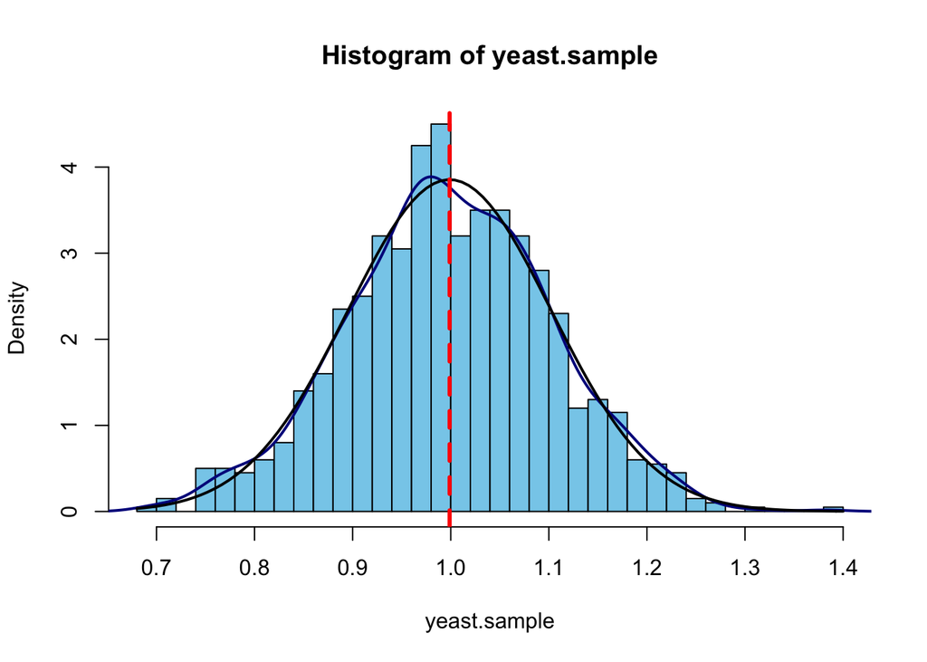

```r
# histograms

# base R
hist(yeast.sample, prob=TRUE, col="skyblue", breaks=40)
lines(density(yeast.sample), col="darkblue", lwd=2)
curve(dnorm(x, mean=y.mean, sd=y.sd),
      lwd=2, add=TRUE, yaxt="n")
abline(v=y.mean, col="red", lwd=3, lty=2)
```

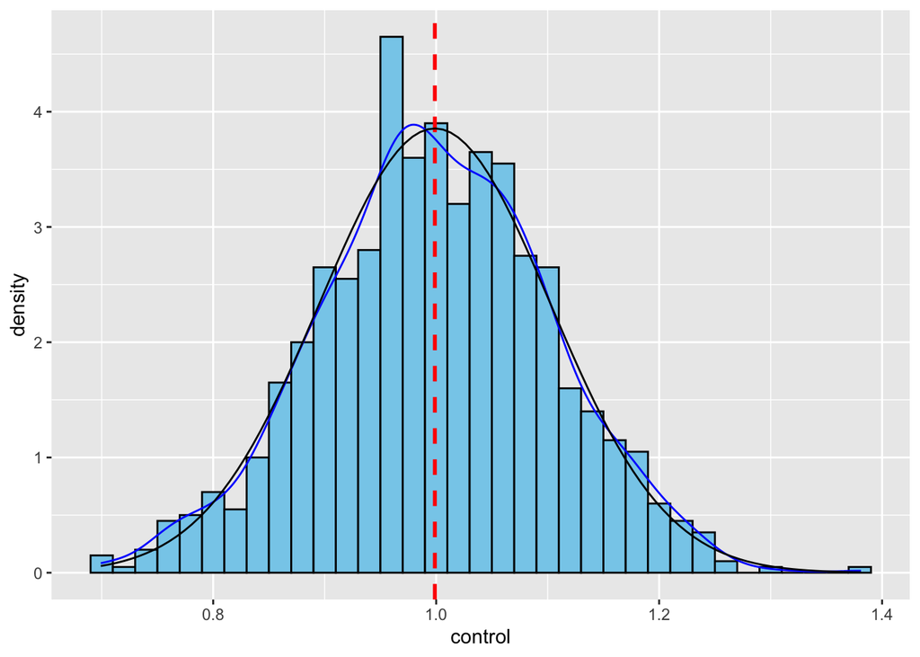

```r
# ggplot
yeast.sample.df = data.frame(control = yeast.sample)

ggplot(yeast.sample.df, aes(x=control)) +
  geom_histogram(aes(y = ..density..),
                 color = "black", fill = "skyblue", binwidth=0.02) +
  geom_vline(xintercept = y.mean, linetype="dashed",
             color = "red", size=1) +
  geom_line(aes(y = ..density..),
            stat = 'density', col="blue") +
  stat_function(fun = dnorm,
                args = list(mean = y.mean,
                            sd = y.sd),
                col = "black")
```

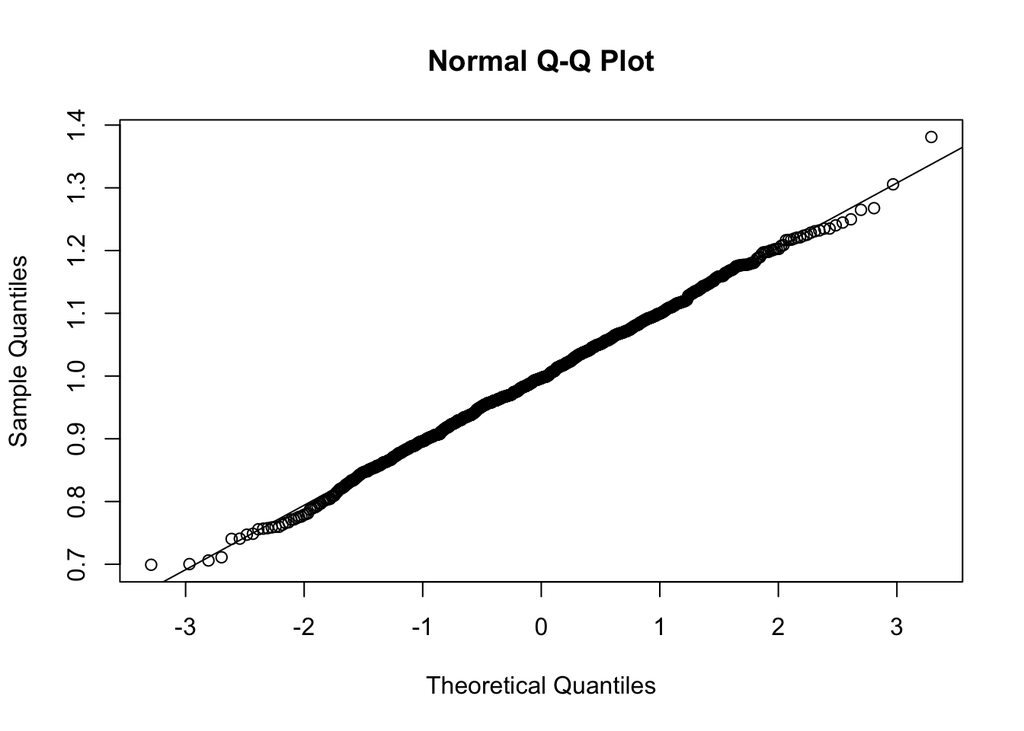

```r
# qqplot
qqnorm(yeast.sample)
qqline(yeast.sample)
```

Use the R functions for the CDF (`pnorm()`) and inverse CDF (`qnorm()`) to answer questions d-f below.

#### d. What is the total probability that a randomly sampled colony from the parent population measures between 0.93 and 1.07 mm?

```r
pnorm(1.07, mean= y.mean, sd = y.sd) - pnorm(0.93, mean= y.mean, sd = y.sd)
```

```
## [1] 0.5011756
```

#### e. What is the proportion of data that are <1 or >1 standard deviations away from the mean?

```r
pnorm(y.mean - y.sd, y.mean, y.sd) + pnorm(y.mean + y.sd, y.mean, y.sd, lower.tail=FALSE)
```

```
## [1] 0.3173105
```

#### f. What diameters correspond to the 10% and 90% quantiles?

```r
c(qnorm(0.1,y.mean,y.sd),qnorm(0.9,y.mean,y.sd))
```

```
## [1] 0.8662054 1.1314650
```

# 2. Co-occurrence of infection

Among women voluntarily tested for sexually transmitted diseases in one university (modified from Tábora et al. 2005):

- 18% tested positive for human papilloma virus (HPV) only,
- 2% tested positive for Chlamydia only, and
- 3% tested positive for both HPV and Chlamydia.

#### a. What is the total frequency of each STD in the population?

```r
# your answer here

# probabilities
p.hpv = 0.18
p.chl = 0.02
p.hpv.chl = 0.03

p.hpv.tot = p.hpv + p.hpv.chl
p.chl.tot = p.chl + p.hpv.chl
p.hpv.tot
```

```
## [1] 0.21
```

```r
p.chl.tot
```

```
## [1] 0.05
```

For the next 3 questions, use set notation to write out the question in terms of set operations (as a comment) and then compute the answer. You may write probabilities using the following syntax, e.g.:

- P(A) * P(B)
- P(A) + P(B)
- P(A AND B)
- P(A OR B)
- P(A | B)
- etc.

#### b. What is the probability that a woman will test positive for Chlamydia, given that she is positive for HPV?

```r
# your answer here

# conditional probability
# P(Ch | HPV) = P(Ch AND HPV) / P(HPV)

p.chl.given.hpv = p.hpv.chl / p.hpv.tot
p.chl.given.hpv
```

```
## [1] 0.1428571
```

#### c. What is the probability that a woman who tests positive for Chlamydia will also test positive HPV?

```r
# your answer here

# conditional probability
# P(HPV | Ch) = P(Ch AND HPV) / P(Ch)

p.hpv.given.chl = p.hpv.chl / p.chl.tot
p.hpv.given.chl
```

```
## [1] 0.6
```

#### d. What is the total probability that a woman from this population who gets tested would test positive for either HPV and/or Chlamydia?

```r
# your answer here

# P(HPV OR Chlamydia) = P(HPV) + P(Chlamydia) - P(HPV AND Chlamydia)
p.hpv.tot + p.chl.tot - p.hpv.chl
```

```
## [1] 0.23
```

```r
# this is the same as adding up the original numbers
p.hpv + p.chl + p.hpv.chl
```

```
## [1] 0.23
```

#### e. Is the occurrence of these infections independent? Explain.

```r
# your answer here

# Independence: P(HPV AND Chlamydia) = P(HPV) * P(Chlamydia)
indep.test = p.hpv.tot * p.chl.tot
indep.test
```

```
## [1] 0.0105
```

```r
indep.test == p.hpv.chl
```

```
## [1] FALSE
```

```r
# No - the joint probability is not the product of the individual probabilities.
```

# 3. Allele frequencies

Many gene loci have a major allele and a number of minor alleles in the population. Let’s say there are 5 alleles for a particular locus, that individuals mate randomly with respect to the genotype at this locus, and that allele frequencies for A1-A5 are 0.82, 0.06, 0.05, 0.04, and 0.03 respectively.

For each of the questions below, write out the probability equations (e.g. P(Ai) for each term) and then compute the answers numerically.

#### a. What is the probability that any single allele chosen at random from the population is either A2 or A5? Write out the probability statement as a comment below and then computer the answer.

```r
# Allele frequencies
A1 = 0.82
A2 = 0.06
A3 = 0.05
A4 = 0.04
A5 = 0.03

# Probability of either A2 or A5 = ?

# P(A2 OR A5) = P(A2) + P(A5)
A2 + A5
```

```
## [1] 0.09
```

#### b. What is the probability that an individual carries two A3 alleles?

```r
# P(A3 AND A3) = P(A3)*P(A3)
A3*A3
```

```
## [1] 0.0025
```

#### c. What is the probability that someone does NOT carry two A3 alleles?

```r
# P(not (A3 AND A3)) = 1 - P(A3 AND A3)
1 - A3^2
```

```
## [1] 0.9975
```

#### d. What is the probability that someone is heterozygous for A1 and A4?

```r
# P(A1 AND A4) = 2 * P(A1)*P(A4)  # since can inherit A1,A4 or A4,A1
2*A1*A4
```

```
## [1] 0.0656
```

#### e. What is the probability that *neither* of two random individuals in the population would carry two A1 alleles?

*Hint: first consider (i) the probability of carrying two A1 alleles, then (ii) the probability of NOT having two A1 alleles, and finally (iii) the probability that 2 individuals are not carrying two A1 alleles.*

```r
# P(A1,A1) = P(A1)*P(A1)          # prob of carrying two A1 alleles
# P(! (A1,A1)) = 1 - P(A1)*P(A1)  # prob of NOT having two A1 alleles

# P(2 individuals are NOT A1,A1) = (1 - P(A1)*P(A1)) * (1 - P(A1)*P(A1))
(1-A1*A1)^2
```

```
## [1] 0.1073218
```

#### f. *Extra credit:* What is the probability that 3 random individuals carry no A3 or A4 alleles at all? (Remember that each individual carries two alleles.)

```r
# P(A3 or A4) = P(A3) + P(A4)        # prob of an allele being A3 or A4
# P(! (A3 or A4)) = 1 - P(A3 or A4)  # prob of an allele not being A3 or A4

# P(neither of 2 alleles is A3 or A4) = [ 1 - P(A3 or A4) ]^2
# P(3 people have no A3 or A4 alleles) = [ [ 1 - P(A3 or A4) ]^2 ]^3
p3or4 = A3 + A4
pNOT3or4 = 1 - p3or4
pNOT3or4^6 # 3 invididuals * 2 alleles each
```

```
## [1] 0.5678693
```

# 4. Trait inheritance

Some people are hypersensitive to the smell of asparagus, and can even detect a strong odor in the urine of a person who has recently eaten asparagus. This trait turns out to have a simple genetic basis (Online Mendelian Inheritance in Man, 2019):

- An individual with one or two copies of the $A$ allele at the gene ($AA$ or $Aa$ genotypes) can smell asparagus in urine, whereas
- a person with two copies of the alternative $a$ allele ($aa$ genotypes) cannot.

**In the human population, 5% of alleles are $A$ and 95% are $a$.**

Assume that men and women in the population have the same allele frequencies at the asparagus-smelling gene and that marriage and child production are independent of the genotype at the gene.

#### a. What is the probability that a randomly sampled individual from the population has two copies of the $a$ allele (that is, that it has an $aa$ genotype)?

*Note: below we suggest to use a list to hold all of the different variables you will need to calculate, to help you keep track of the combinations. A list uses similar syntax to a data frame, except it can hold any kind of data of any size.*

```r
Pr=list()
Pr$a=0.95
Pr$A=0.05

Pr$aa = Pr$a * Pr$a
Pr$aa
```

```
## [1] 0.9025
```

#### b. What is the probability that both members of a randomly sampled married couple (man and woman) are $aa$ at the asparagus-smelling gene?

```r
Pr$aa_aa = Pr$aa * Pr$aa
Pr$aa_aa
```

```
## [1] 0.8145062
```

#### c. What is the probability that both members of a randomly sampled married couple (man and woman) are heterozygotes at this locus (meaning that each person has one allele $A$ and one allele $a$)? Remember that each allele can be inherited from either parent.

```r
# first calculate probability that one individual is heterozygous
# Aa (mother A, father a) and aA (mother a, father A) are the same, so multiply by 2
Pr$Aa = Pr$A * Pr$a + Pr$a * Pr$A
Pr$Aa
```

```
## [1] 0.095
```

```r
# probability that both parents are heterozygous
Pr$Aa_Aa = Pr$Aa * Pr$Aa
Pr$Aa_Aa
```

```
## [1] 0.009025
```

#### d. What is the conditional probability that the first child of the couple in (c) is an $aa$ homozygote? Remember that the child must receive exactly one allele from each parent.

*Beware: here you need to consider transmission probabilities, not the allele frequencies in the population! Think “Punnett square”.*

```r
# conditional probability that Aa x Aa -> Aa
Pr$Caa.FAa_MAa = 0.25
Pr$Caa.FAa_MAa
## [1] 0.25
```

#### e. Above we figured out the probability that a child of known parentage inherits a particular allele combination. What if we want to turn this around and ask, *If a randomly sampled child has the $aa$ genotype, what is the probability that both its parents were both $Aa$ heterozygotes?*

To answer this we need to use **Bayes’ Theorem**. Recall the definition of conditional probability:

$$P(F_{Aa} M_{Aa} | C_{aa}):= \frac{P(F_{Aa} M_{Aa} \cap C_{aa}) }{ P(C_{aa}) }$$
and

$$P(C_{aa} | F_{Aa} M_{Aa}):= \frac{P(F_{Aa} M_{Aa} \cap C_{aa}) }{ P(F_{Aa} M_{Aa}) }$$

Therefore, the intersection (co-occurrence) of the parental and child alleles can be written equivalently as:

$$P(F_{Aa} M_{Aa} \cap C_{aa}) = P(F_{Aa} M_{Aa} | C_{aa}) * P(C_{aa}) = P(C_{aa}|F_{Aa}M_{Aa}) * P(F_{Aa}M_{Aa})$$

Fantastic! Now we have what we need to find the desired *posterior probability* $P(F_{Aa} M_{Aa} | C_{aa})$, given the known

- *priors* $P(F_{alleles}M_{alleles})$ and
- *likelihoods* $P(C_{aa}|F_{alleles}M_{alleles})$.

All we have to do is rearrange this equation and use Bayes Theorem:

$$P(F_{Aa} M_{Aa} | C_{aa}) = \frac{P(C_{aa}|F_{Aa}M_{Aa}) * P(F_{Aa}M_{Aa})}{P(C_{aa})} = \frac{P(C_{aa}|F_{Aa}M_{Aa}) * P(F_{Aa}M_{Aa})}{\sum_{ij} P(C_{aa}|F_iM_j) * P(F_iM_j)}$$

where $i,j \in \{AA, Aa, aA, aa\}$.

This equation represents *the fraction of the time that we expect to see one particular combination of parental alleles given an $aa$ child (i.e. both parents are $Aa$ heterozygotes), relative to all the possible ways a child could inherit two $a$ alleles.*

To compute the *posterior probability*, we need to first quantify a bunch of individual probabilities, so let’s break the problem into pieces and compute the required components in stages:

- **i. Probabilities of each allele combination in any individual in the population (parental frequencies):**

```r
# probabilities of each allele combination in the parents
Pr$AA = Pr$A * Pr$A # P(AA)
Pr$Aa = Pr$A * Pr$a # P(Aa)
Pr$aA = Pr$a * Pr$A # P(aA)
Pr$aa = Pr$a * Pr$a # P(aa)

Pr$AA
## [1] 0.0025
Pr$Aa
## [1] 0.0475
Pr$aA
## [1] 0.0475
Pr$aa
## [1] 0.9025
```

- **ii. *Priors* for each combination of parental alleles (states of nature):**

```r
# priors for each combination of parental alleles
Pr$Faa_Maa = Pr$aa * Pr$aa
Pr$FAa_Maa = Pr$Aa * Pr$aa
Pr$FAA_Maa = Pr$AA * Pr$aa
Pr$Faa_MAa = Pr$aa * Pr$Aa
Pr$FAa_MAa = Pr$Aa * Pr$Aa
Pr$FAA_MAa = Pr$AA * Pr$Aa
Pr$Faa_MAA = Pr$aa * Pr$AA
Pr$FAa_MAA = Pr$Aa * Pr$AA
Pr$FAA_MAA = Pr$AA * Pr$AA

Pr$Faa_Maa
## [1] 0.8145062
Pr$FAa_Maa
## [1] 0.04286875
Pr$FAA_Maa
## [1] 0.00225625
Pr$Faa_MAa
## [1] 0.04286875
Pr$FAa_MAa
## [1] 0.00225625
Pr$FAA_MAa
## [1] 0.00011875
Pr$Faa_MAA
## [1] 0.00225625
Pr$FAa_MAA
## [1] 0.00011875
Pr$FAA_MAA
## [1] 6.25e-06
```

- **iii. *Likelihoods* (conditional probabilities) for $C_{aa}$ given each combination of parental alleles:**

```r
# individual likelihoods (think Punnett square)
Pr$Caa.Faa_Maa = 1
Pr$Caa.FAa_Maa = 0.5
Pr$Caa.FAA_Maa = 0
Pr$Caa.Faa_MAa = 0.5
Pr$Caa.FAa_MAa = 0.25
Pr$Caa.FAA_MAa = 0
Pr$Caa.Faa_MAA = 0
Pr$Caa.FAa_MAA = 0
Pr$Caa.FAA_MAA = 0
```

- **iv. *Total probability* $Pr(C_{aa})$ that the child is $aa$ (the denominator):**

To find this, unfortunately need to consider the probabilities of all possible combinations of parental allele contributions, or possible *states of nature*:

$$\begin{aligned}P(C_{aa}) =& P(C_{aa}|F_{aa}M_{aa}) * P(F_{aa}M_{aa}) \ + \\
& P(C_{aa}|F_{Aa}M_{aa}) * P(F_{Aa}M_{aa}) \ + \\
& P(C_{aa}|F_{AA}M_{aa}) * P(F_{AA}M_{aa}) \ + \\
& P(C_{aa}|F_{aa}M_{Aa}) * P(F_{aa}M_{Aa}) \ + \\
& P(C_{aa}|F_{Aa}M_{Aa}) * P(F_{Aa}M_{Aa}) \ + \\
& P(C_{aa}|F_{AA}M_{Aa}) * P(F_{AA}M_{Aa}) \ + \\
& P(C_{aa}|F_{aa}M_{AA}) * P(F_{aa}M_{AA}) \ + \\
& P(C_{aa}|F_{Aa}M_{AA}) * P(F_{Aa}M_{AA}) \ + \\
& P(C_{aa}|F_{AA}M_{AA}) * P(F_{AA}M_{AA})
\end{aligned}$$

```r
# total probability P(C_aa)
Pr$Caa = Pr$Caa.Faa_Maa * (Pr$aa * Pr$aa) +
         Pr$Caa.FAa_Maa * (Pr$Aa * Pr$aa) +
         Pr$Caa.FAA_Maa * (Pr$AA * Pr$aa) +
         Pr$Caa.Faa_MAa * (Pr$aa * Pr$Aa) +
         Pr$Caa.FAa_MAa * (Pr$Aa * Pr$Aa) +
         Pr$Caa.FAA_MAa * (Pr$AA * Pr$Aa) +
         Pr$Caa.Faa_MAA * (Pr$aa * Pr$AA) +
         Pr$Caa.FAa_MAA * (Pr$Aa * Pr$AA) +
         Pr$Caa.FAA_MAA * (Pr$AA * Pr$AA)

Pr$Caa
```

```
## [1] 0.8579391
```

- **v. Finally, we can plug the desired variables from above into the original Bayes equation to find the *posterior probability:***

$$P(F_{Aa}M_{Aa} | C_{aa}) = \frac{P(C_{aa}|F_{Aa}M_{Aa}) * P(F_{Aa}M_{Aa})}{P(C_{aa})}$$

```r
# Posterior probability of P(F_Aa, M_Aa | C_Aa):
Pr$FAa_MAa.Caa = Pr$Caa.FAa_MAa * (Pr$Aa * Pr$Aa) / Pr$Caa
Pr$FAa_MAa.Caa
```

```
## [1] 0.0006574622
```

#### f. If a randomly sampled child has the $aa$ genotype, what is the probability that both its parents were also $aa$?

The *posterior probability* $P(F_{aa} M_{aa} | C_{aa})$ is:

$$P(F_{aa} M_{aa} | C_{aa}) = \frac{P(C_{aa}|F_{aa}M_{aa}) * P(F_{aa}M_{aa})}{P(C_{aa})} = \frac{P(C_{aa}|F_{aa}M_{aa}) * P(F_{aa}M_{aa})}{\sum_{ij} P(C_{aa}|F_iM_j) * P(F_iM_j)}$$

We computed all the relevant quantities above, so now this should be easy!

```r
Pr$Faa_Maa.Caa = Pr$Caa.Faa_Maa * Pr$Faa_Maa / Pr$Caa
Pr$Faa_Maa.Caa
```

```
## [1] 0.9493754
```